# Submission 2 - Intermediate

**Instructions**

- Fill out the 'Basic Information' and 'Simple Hypotheses - Findings / Insights' sections (replace the TODOs with your information)
  - If your visualization is interactive, create a short video that shows the interactivity (max. 3 min).
- Export the Jupyter notebook as a HTML file and save it in this repository.
  - Go to 'File' -> 'Save and Export Notebook As..' -> 'HTML'.
  - Save it locally in your project folder. You can leave the name as it is.
  - If you have a video, then add it to the project folder.
  - Push your local changes to the GitHub repository.
- Upload the generated HTML for the Moodle submission.
  - If you have a video, then upload that for the Moodle submission, too.

## Basic Information

**Team Name:** covid_2022

**Team Members:**

- Andeol Albitre
- Ábel Boros
- Felix Breiteneder
- Angelika Vižintin

**Dataset Description:**  
(max. 75 words)

Our dataset includes numerous statistics about the Covid-19 pandemic in Austria since its beginning. Daily number of infections, hospitalization and deaths are available among different age groups. Moreover, all of the data is aggregatable by states and disctricts. Additionally, the dataset also includes vaccine, test and available hospital beds statistics.

## Simple Hypotheses - Findings / Insights

**Instructions:**

- Add your visualizations (**max. 4**) here
  - The visualizations should show the findings / insights
- Add the descriptions for all your findings / insights (**max. 150 words**)
  - The description should also relate to the visualizations above.

## Hypothesis 1

### The number of deaths of COVID-19 patients is the highest in the 85+ group in all Austria.

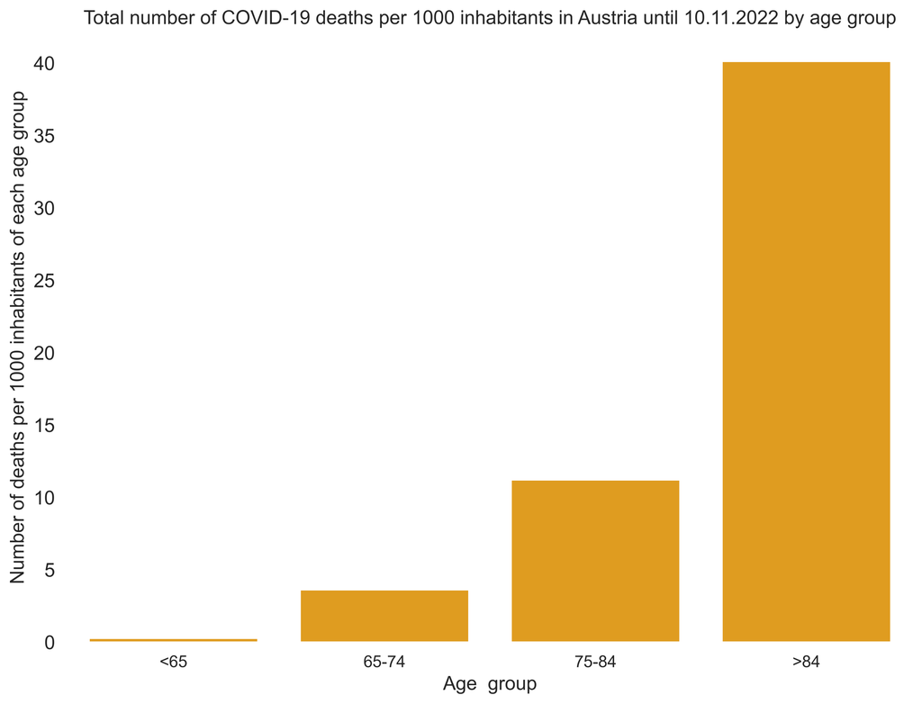

Figure 1: Total number of COVID-19 deaths per 1000 inhabitants in Austria until 10.11.2022 by age group (source of data: dataset CovidFaelle_Altersgruppe.csv from https://covid19-dashboard.ages.at/).

[figure not shown]

Figure 2: Comulative number of COVID-19 deaths per 1000 inhabitants in Austria from 26.2.2020 until 10.11.2022 by age group (source of data: dataset CovidFaelle_Altersgruppe.csv from https://covid19-dashboard.ages.at/).

## Hypothesis 2

### The number of new daily Covid-19 infections in Austria does vary between seasons

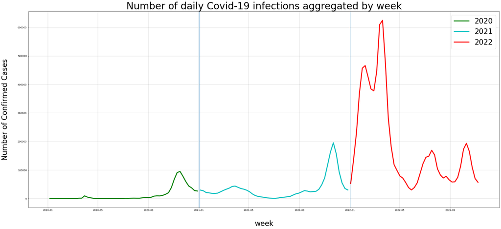

Figure 3: Number of daily Covid-19 in Austria (source of data: CovidFaelle_Timeline_edited_2.csv from https://covid19-dashboard.ages.at/).

[figure not shown]

Figure 4: Number of Covid-19 infections by season in Austria (source of data: CovidFaelle_Timeline_edited_2.csv from https://covid19-dashboard.ages.at/).

## Hypothesis 1 Description

The aim of Figure 1 and 2 is to investigate the first hypothesis. The displayed data on both figures were normalized by the total number of inhabitants of each age group, excluding the possibility that the number of deaths in one age group would appear high only because it is the largest group. Both figures support the hypothesis that the number of deaths is the highest in the 85+ group.

## Hypothesis 2 Description

Both visualisations support our hypothesis that daily Covid-19 infections do vary between seasons. It is clearly visible that there are temporal differences in the number of daily infections. In the first two years during the pandemic, in the winter months Covid infections did increase significantly compared to the warmer seasons. In the current year a new trend can be seen, that Covid infections arise in waves independent of the season.